# Regression Diagnostics and Model Evaluation of Housing Prices

Isuri Nawodya Herath S W M M G

2026-01-13

# 1 Introduction

Regression analysis serves as a foundational tool in predictive analytics, enabling researchers and practitioners to understand relationships between variables and make informed predictions. This report presents a comprehensive regression analysis of the Ames Housing dataset, which contains detailed information about residential property sales in Ames, Iowa, from 2006 to 2010.

The primary objective is to develop, evaluate, and refine multiple linear regression models capable of accurately predicting housing sale prices based on various property characteristics. The analysis emphasizes identification and correction of common regression issues including non-linearity, multicollinearity, outliers, and influential observations.

# 2 Setup

## 2.1 Load Packages

```r
# install.packages(c("tidyverse", "car", "corrplot", "ggcorrplot", "leaps"))

library(tidyverse)
library(car)
library(corrplot)
library(ggcorrplot)
library(leaps)
```

## 2.2 Load Data

```r
ames_data <- read.csv("AmesHousing.csv")

# Clean column names by removing dots
names(ames_data) <- gsub("\\.", "", names(ames_data))

# Remove Order column
ames_data <- ames_data %>% select(-Order)

glimpse(ames_data)
```

```
## Rows: 2,930
## Columns: 81
## $ PID           <int> 526301100, 526350040, 526351010, 526353030, 527105010, 5…
## $ MSSubClass    <int> 20, 20, 20, 20, 60, 60, 120, 120, 120, 60, 60, 20, 60, 2…
## $ MSZoning      <chr> "RL", "RH", "RL", "RL", "RL", "RL", "RL", "RL", "RL", "R…
## $ LotFrontage   <int> 141, 80, 81, 93, 74, 78, 41, 43, 39, 60, 75, NA, 63, 85,…
## $ LotArea       <int> 31770, 11622, 14267, 11160, 13830, 9978, 4920, 5005, 538…
## $ Street        <chr> "Pave", "Pave", "Pave", "Pave", "Pave", "Pave", "Pave", …
## $ Alley         <chr> NA, NA, NA, NA, NA, NA, NA, NA, NA, NA, NA, NA, NA, NA, …
## $ LotShape      <chr> "IR1", "Reg", "IR1", "Reg", "IR1", "IR1", "Reg", "IR1", …
## $ LandContour   <chr> "Lvl", "Lvl", "Lvl", "Lvl", "Lvl", "Lvl", "Lvl", "HLS", …
## $ Utilities     <chr> "AllPub", "AllPub", "AllPub", "AllPub", "AllPub", "AllPu…
## $ LotConfig     <chr> "Corner", "Inside", "Corner", "Corner", "Inside", "Insid…
## $ LandSlope     <chr> "Gtl", "Gtl", "Gtl", "Gtl", "Gtl", "Gtl", "Gtl", "Gtl", …
## $ Neighborhood  <chr> "NAmes", "NAmes", "NAmes", "NAmes", "Gilbert", "Gilbert"…
```

[output cut: 68 more lines]

# 3 Exploratory Data Analysis

## 3.1 Variable Types

```r
numeric_vars <- ames_data %>% select_if(is.numeric)
categorical_vars <- ames_data %>% select_if(is.character)

cat("Numeric variables:", ncol(numeric_vars), "\n")
```

```
## Numeric variables: 38
```

```r
cat("Categorical variables:", ncol(categorical_vars), "\n")
```

```
## Categorical variables: 43
```

```r
cat("Total observations:", nrow(ames_data), "\n")
```

```
## Total observations: 2930
```

## 3.2 Missing Values

```r
missing_summary <- data.frame(
  Variable = names(ames_data),
  Missing_Count = colSums(is.na(ames_data)),
  Missing_Percent = round(colSums(is.na(ames_data)) / nrow(ames_data) * 100, 2)
)
missing_summary <- missing_summary[missing_summary$Missing_Count > 0, ]
missing_summary <- missing_summary[order(-missing_summary$Missing_Count), ]
print(missing_summary)
```

```
##                  Variable Missing_Count Missing_Percent
## PoolQC             PoolQC          2917           99.56
## MiscFeature   MiscFeature          2824           96.38
## Alley               Alley          2732           93.24
## Fence               Fence          2358           80.48
## FireplaceQu   FireplaceQu          1422           48.53
## LotFrontage   LotFrontage           490           16.72
## GarageYrBlt   GarageYrBlt           159            5.43
## GarageQual     GarageQual           158            5.39
## GarageCond     GarageCond           158            5.39
## GarageType     GarageType           157            5.36
## GarageFinish GarageFinish           157            5.36
## BsmtQual         BsmtQual            79            2.70
## BsmtCond         BsmtCond            79            2.70
## BsmtExposure BsmtExposure            79            2.70
## BsmtFinType1 BsmtFinType1            79            2.70
## BsmtFinType2 BsmtFinType2            79            2.70
## MasVnrArea     MasVnrArea            23            0.78
## BsmtFullBath BsmtFullBath             2            0.07
## BsmtHalfBath BsmtHalfBath             2            0.07
## BsmtFinSF1     BsmtFinSF1             1            0.03
## BsmtFinSF2     BsmtFinSF2             1            0.03
## BsmtUnfSF       BsmtUnfSF             1            0.03
## TotalBsmtSF   TotalBsmtSF             1            0.03
## GarageCars     GarageCars             1            0.03
## GarageArea     GarageArea             1            0.03
```

## 3.3 Distributions of Key Numeric Variables

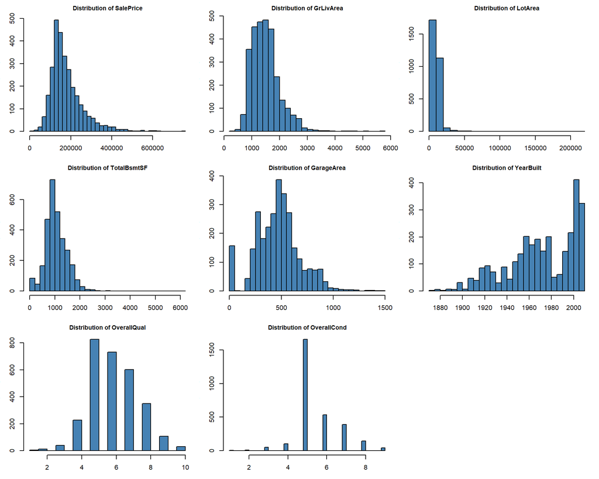

```r
key_vars <- c("SalePrice", "GrLivArea", "LotArea", "TotalBsmtSF",
              "GarageArea", "YearBuilt", "OverallQual", "OverallCond")
key_vars <- key_vars[key_vars %in% names(ames_data)]

par(mfrow = c(3, 3), mar = c(3, 3, 2, 1))
for (var in key_vars) {
  hist(ames_data[[var]],
       main = paste("Distribution of", var),
       xlab = var,
       col = "steelblue",
       breaks = 30,
       cex.main = 0.9)
}
par(mfrow = c(1, 1))
```

The histograms reveal several important distributional characteristics:

- **SalePrice** - right-skewed with most properties selling between $100,000 and $250,000
- **GrLivArea** - approximately normal, centered around 1,500 sq ft
- **LotArea** - severely right-skewed with extreme outliers exceeding 150,000 sq ft
- **YearBuilt** - bimodal pattern with peaks around 1960 and 2000–2010
- **OverallQual** - approximately normal, centered at ratings 5–6

## 3.4 Outlier Detection via Boxplots

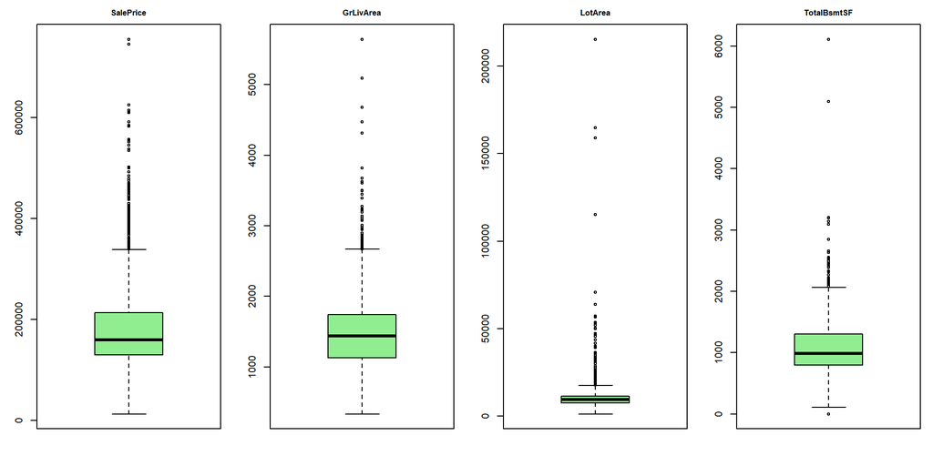

```r
par(mfrow = c(1, 4), mar = c(3, 3, 2, 1))
boxplot_vars <- c("SalePrice", "GrLivArea", "LotArea", "TotalBsmtSF")
for (var in boxplot_vars) {
  boxplot(ames_data[[var]],
          main = var,
          col = "lightgreen",
          cex.main = 0.8)
}
```

```r
par(mfrow = c(1, 1))
```

## 3.5 SalePrice Detailed Analysis

```r
# Summary statistics
saleprice_stats <- ames_data %>%
  summarise(
    Mean   = round(mean(SalePrice, na.rm = TRUE), 2),
    Median = round(median(SalePrice, na.rm = TRUE), 2),
    SD     = round(sd(SalePrice, na.rm = TRUE), 2),
    Min    = round(min(SalePrice, na.rm = TRUE), 2),
    Max    = round(max(SalePrice, na.rm = TRUE), 2),
    Q1     = round(quantile(SalePrice, 0.25, na.rm = TRUE), 2),
    Q3     = round(quantile(SalePrice, 0.75, na.rm = TRUE), 2)
  )
print(saleprice_stats)
```

```
##       Mean Median       SD   Min    Max     Q1     Q3
## 1 180796.1 160000 79886.69 12789 755000 129500 213500
```

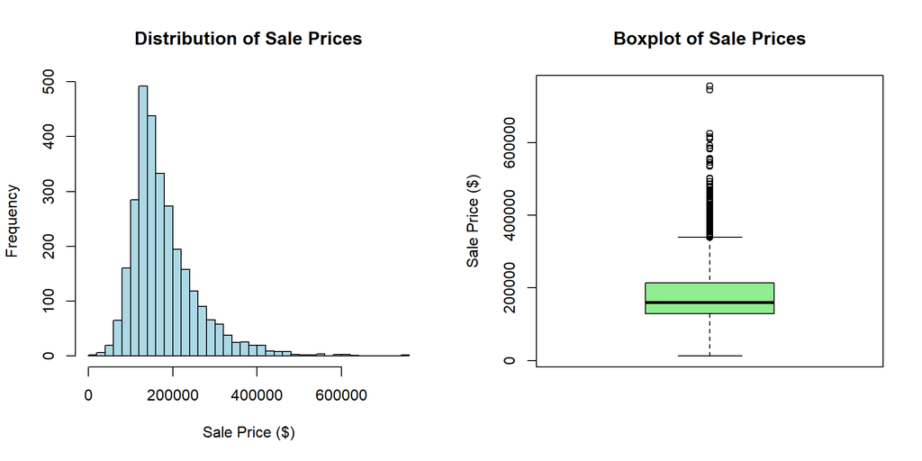

```r
# Histogram and boxplot side by side
par(mfrow = c(1, 2))
hist(ames_data$SalePrice,
     main = "Distribution of Sale Prices",
     xlab = "Sale Price ($)",
     col = "lightblue",
     breaks = 50)
boxplot(ames_data$SalePrice,
        main = "Boxplot of Sale Prices",
        ylab = "Sale Price ($)",
        col = "lightgreen")
```

```r
par(mfrow = c(1, 1))
```

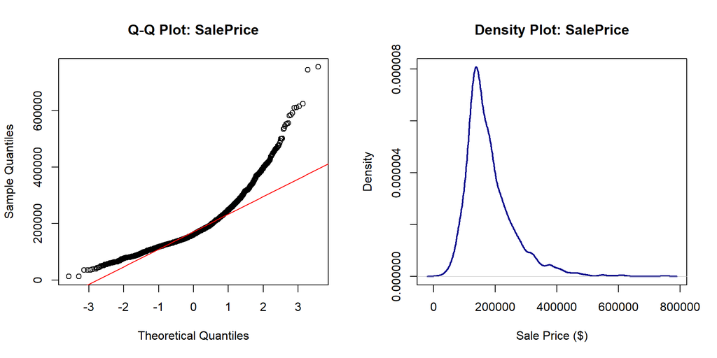

```r
# Q-Q plot and density plot
par(mfrow = c(1, 2))
qqnorm(ames_data$SalePrice, main = "Q-Q Plot: SalePrice")
qqline(ames_data$SalePrice, col = "red")

plot(density(ames_data$SalePrice, na.rm = TRUE),
     main = "Density Plot: SalePrice",
     xlab = "Sale Price ($)",
     col = "darkblue",
     lwd = 2)
```

```r
par(mfrow = c(1, 1))
```

# 4 Correlation Analysis

## 4.1 Data Preparation - Impute Missing Values

```r
# Create HouseAge variable
ames_clean <- ames_data

if ("YearBuilt" %in% names(ames_clean) && "YrSold" %in% names(ames_clean)) {
  ames_clean$HouseAge <- ames_clean$YrSold - ames_clean$YearBuilt
}

# Remove variables with >30% missing
ames_clean <- ames_clean %>%
  select(-Alley, -FireplaceQu, -PoolQC, -Fence, -MiscFeature)

# Impute numeric missing values with column mean
numeric_columns <- names(ames_clean)[sapply(ames_clean, is.numeric)]
for (col in numeric_columns) {
  if (sum(is.na(ames_clean[[col]])) > 0) {
    ames_clean[[col]][is.na(ames_clean[[col]])] <- mean(ames_clean[[col]], na.rm = TRUE)
  }
}

cat("Missing values remaining:", sum(colSums(is.na(ames_clean))), "\n")
```

```
## Missing values remaining: 1025
```

## 4.2 Correlation Matrix

```r
numeric_vars <- ames_clean %>% select_if(is.numeric) %>% select(-PID)
cor_matrix <- cor(numeric_vars, use = "complete.obs")

# Top correlations with SalePrice
saleprice_cor <- cor_matrix[, "SalePrice"]
saleprice_cor_sorted <- sort(abs(saleprice_cor), decreasing = TRUE)
print(head(saleprice_cor_sorted, 15))
```

```
##    SalePrice  OverallQual    GrLivArea   GarageCars   GarageArea  TotalBsmtSF
##    1.0000000    0.7992618    0.7067799    0.6478611    0.6403855    0.6321051
##    X1stFlrSF     HouseAge    YearBuilt     FullBath YearRemodAdd  GarageYrBlt
##    0.6216761    0.5589068    0.5584261    0.5456039    0.5329738    0.5106844
##   MasVnrArea TotRmsAbvGrd   Fireplaces
##    0.5057841    0.4954744    0.4745581
```

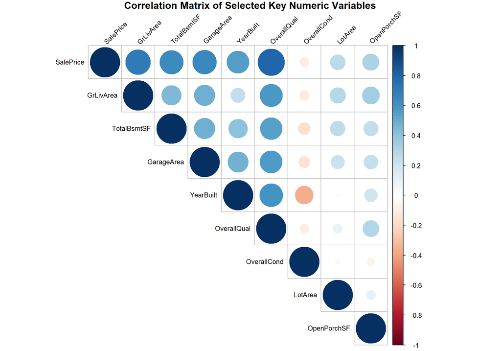

```r
# Focused correlation plot for key variables
key_numeric_vars <- numeric_vars %>%
  select(SalePrice, GrLivArea, TotalBsmtSF, GarageArea,
         YearBuilt, OverallQual, OverallCond, LotArea, OpenPorchSF)

cor_matrix_key <- cor(key_numeric_vars, use = "complete.obs")

corrplot(
  cor_matrix_key,
  method = "circle",
  type = "upper",
  tl.col = "black",
  tl.srt = 45,
  tl.cex = 0.8,
  title = "Correlation Matrix of Selected Key Numeric Variables",
  mar = c(0, 0, 1, 0)
)
```

Key correlations with `SalePrice`: `OverallQual` (r = 0.80), `GrLivArea` (r = 0.70), `GarageArea` (r = 0.64), `TotalBsmtSF` (r = 0.63), `YearBuilt` (r = 0.56).

## 4.3 Scatterplot Comparison

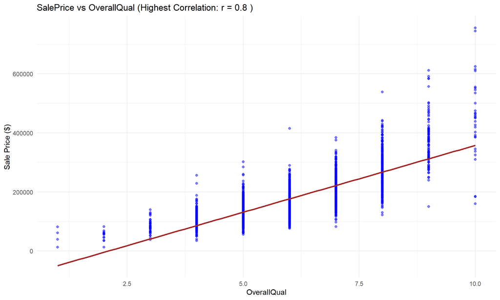

```r
# Identify highest, lowest, and moderate correlations
saleprice_cor_df <- data.frame(
  Variable = names(saleprice_cor),
  Correlation = saleprice_cor
) %>%
  filter(Variable != "SalePrice") %>%
  arrange(desc(abs(Correlation)))

highest_cor_var <- saleprice_cor_df$Variable[1]
lowest_cor_var  <- saleprice_cor_df$Variable[nrow(saleprice_cor_df)]
mid_cor_var     <- saleprice_cor_df$Variable[which.min(abs(abs(saleprice_cor_df$Correlation) - 0.5))]

# Highest correlation
ggplot(numeric_vars, aes(x = .data[[highest_cor_var]], y = SalePrice)) +
  geom_point(color = "blue", alpha = 0.5) +
  geom_smooth(method = "lm", se = FALSE, color = "#A32424") +
  labs(title = paste("SalePrice vs", highest_cor_var,
                     "(Highest Correlation: r =", round(saleprice_cor_df$Correlation[1], 2), ")"),
       x = highest_cor_var, y = "Sale Price ($)") +
  theme_minimal()
```

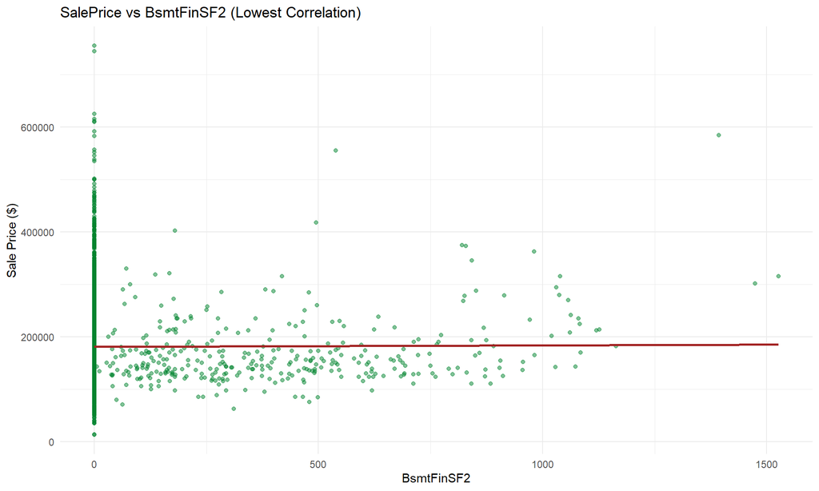

```r
# Lowest correlation
ggplot(numeric_vars, aes(x = .data[[lowest_cor_var]], y = SalePrice)) +
  geom_point(color = "#00832D", alpha = 0.5) +
  geom_smooth(method = "lm", se = FALSE, color = "#A32424") +
  labs(title = paste("SalePrice vs", lowest_cor_var, "(Lowest Correlation)"),
       x = lowest_cor_var, y = "Sale Price ($)") +
  theme_minimal()
```

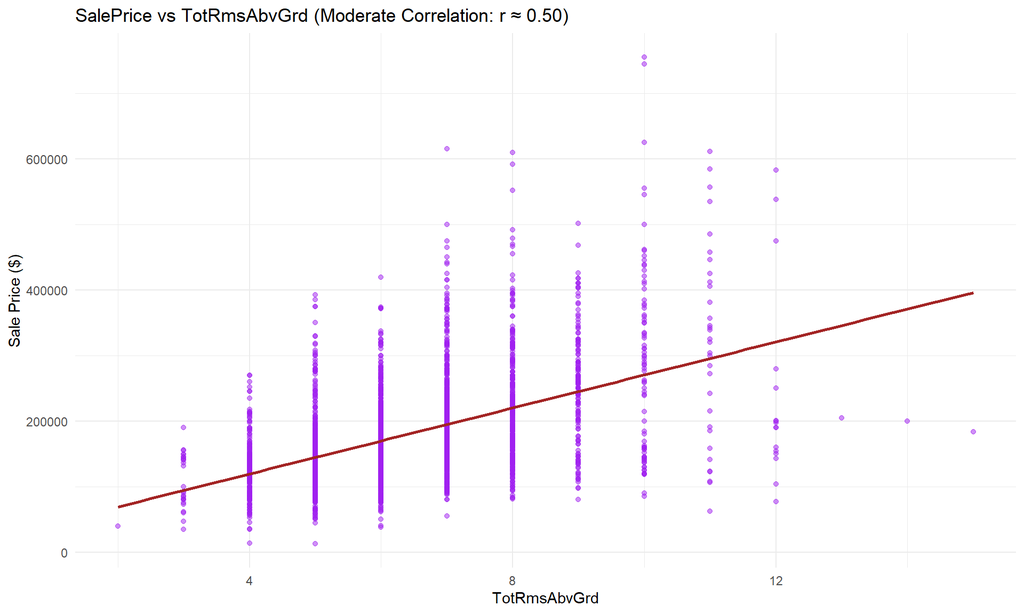

```r
# Moderate correlation
ggplot(numeric_vars, aes(x = .data[[mid_cor_var]], y = SalePrice)) +
  geom_point(color = "purple", alpha = 0.5) +
  geom_smooth(method = "lm", se = FALSE, color = "#A32424") +
  labs(title = paste("SalePrice vs", mid_cor_var, "(Moderate Correlation: r ≈ 0.50)"),
       x = mid_cor_var, y = "Sale Price ($)") +
  theme_minimal()
```

# 5 Initial Regression Model (Model 1)

## 5.1 Fit the Model

```r
model1 <- lm(SalePrice ~ OverallQual + GrLivArea + GarageArea + HouseAge,
             data = ames_clean)

summary(model1)
```

```
##
## Call:
## lm(formula = SalePrice ~ OverallQual + GrLivArea + GarageArea +
##     HouseAge, data = ames_clean)
##
## Residuals:
##     Min      1Q  Median      3Q     Max
## -416029  -22220   -2156   18025  293543
##
## Coefficients:
##               Estimate Std. Error t value            Pr(>|t|)
## (Intercept) -62480.576   4618.026  -13.53 <0.0000000000000002 ***
## OverallQual  23743.791    763.829   31.09 <0.0000000000000002 ***
## GrLivArea       55.812      1.798   31.04 <0.0000000000000002 ***
## GarageArea      60.774      4.256   14.28 <0.0000000000000002 ***
## HouseAge      -380.836     30.536  -12.47 <0.0000000000000002 ***
## ---
## Signif. codes:  0 '***' 0.001 '**' 0.01 '*' 0.05 '.' 0.1 ' ' 1
##
## Residual standard error: 38320 on 2925 degrees of freedom
## Multiple R-squared:  0.7703, Adjusted R-squared:   0.77
## F-statistic:  2452 on 4 and 2925 DF,  p-value: < 0.00000000000000022
```

## 5.2 Model Equation

```r
coef_model1 <- coef(model1)

cat("SalePrice =", round(coef_model1[1], 2),
    "+", round(coef_model1[2], 2), "* OverallQual",
    "+", round(coef_model1[3], 2), "* GrLivArea",
    "+", round(coef_model1[4], 2), "* GarageArea",
    "+", round(coef_model1[5], 2), "* HouseAge\n")
```

```
## SalePrice = -62480.58 + 23743.79 * OverallQual + 55.81 * GrLivArea + 60.77 * GarageArea + -380.84 * HouseAge
```

## 5.3 Coefficient Interpretations

- **OverallQual** - each 1-unit increase in quality rating is associated with ~$23,744 increase in sale price
- **GrLivArea** - each additional square foot of living area increases sale price by ~$55.81
- **GarageArea** - each additional square foot of garage space increases sale price by ~$60.77
- **HouseAge** - each additional year of age decreases sale price by ~$380.84

# 6 Diagnostic Evaluation

## 6.1 Diagnostic Plots

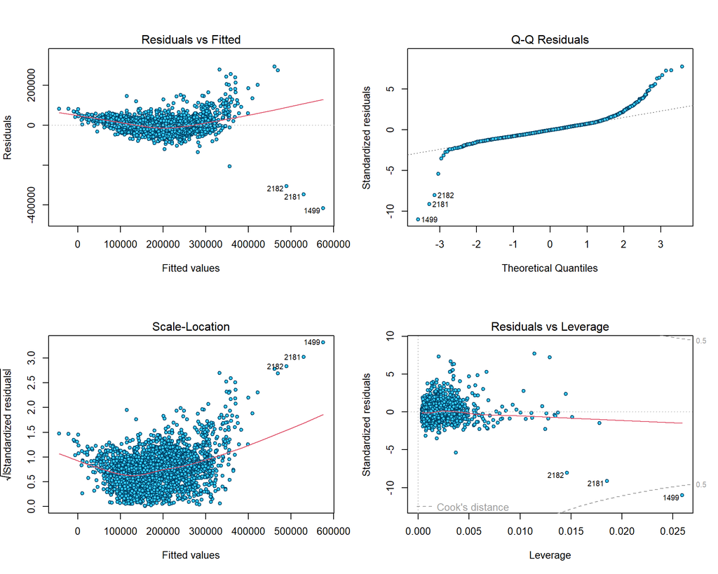

```r
par(mfrow = c(2, 2))
plot(model1, which = 1, pch = 21, bg = "#33ccff", col = "#004466", cex = 0.8)
plot(model1, which = 2, pch = 21, bg = "#33ccff", col = "#004466", cex = 0.8)
plot(model1, which = 3, pch = 21, bg = "#33ccff", col = "#004466", cex = 0.8)
plot(model1, which = 5, pch = 21, bg = "#33ccff", col = "#004466", cex = 0.8)
```

```r
par(mfrow = c(1, 1))
```

- **Residuals vs Fitted** - mild funnel shape at higher fitted values suggesting heteroscedasticity
- **Q-Q Plot** - approximate normality in center; heavy right tail deviation
- **Scale-Location** - slight upward trend confirming mild heteroscedasticity
- **Residuals vs Leverage** - observations 1499, 2181, 2182 near/beyond Cook’s distance 0.5 contour

## 6.2 Multicollinearity Assessment (VIF)

```r
vif_values <- vif(model1)
print(vif_values)
```

```
## OverallQual   GrLivArea  GarageArea    HouseAge
##    2.317481    1.648092    1.670674    1.706947
```

```r
if (any(vif_values > 10)) {
  cat("SEVERE multicollinearity detected - VIF > 10\n")
} else if (any(vif_values > 5)) {
  cat("MODERATE multicollinearity detected - VIF > 5\n")
} else {
  cat("No significant multicollinearity - all VIF values < 5\n")
}
```

```
## No significant multicollinearity - all VIF values < 5
```

## 6.3 Outlier Analysis

```r
# Standardized residuals
std_residuals <- rstandard(model1)
outliers_index <- which(abs(std_residuals) > 3)
cat("Outliers with |standardized residual| > 3:", length(outliers_index), "\n")
```

```
## Outliers with |standardized residual| > 3: 41
```

```r
# Cook's Distance
cooks_d <- cooks.distance(model1)
influential <- which(cooks_d > 4 / nrow(ames_clean))
cat("Influential points (Cook's D > 4/n):", length(influential), "\n")
```

```
## Influential points (Cook's D > 4/n): 166
```

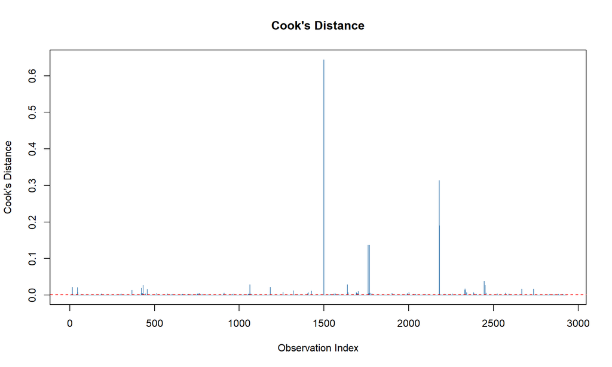

```r
plot(cooks_d, type = "h", col = "steelblue",
     main = "Cook's Distance",
     xlab = "Observation Index",
     ylab = "Cook's Distance")
abline(h = 4 / nrow(ames_clean), col = "red", lty = 2)
```

Three observations stand out dramatically - index ~1500 (Cook’s D > 0.6), ~1700, and ~2200. These properties had above-grade living areas exceeding 4,000 sq ft but sold for prices much lower than predicted, likely representing partial sales or unusual circumstances.

# 7 Improved Model (Model 2)

## 7.1 Remove Outliers and Refit

```r
# Remove properties with GrLivArea > 4000 per dataset documentation
ames_clean2 <- ames_clean[ames_clean$GrLivArea <= 4000, ]
cat("Removed", nrow(ames_clean) - nrow(ames_clean2), "observations with GrLivArea > 4000\n")
```

```
## Removed 5 observations with GrLivArea > 4000
```

```r
# Refit the model
model2 <- lm(SalePrice ~ OverallQual + GrLivArea + GarageArea + HouseAge,
             data = ames_clean2)

summary(model2)
```

```
##
## Call:
## lm(formula = SalePrice ~ OverallQual + GrLivArea + GarageArea +
##     HouseAge, data = ames_clean2)
##
## Residuals:
##     Min      1Q  Median      3Q     Max
## -210906  -22481   -1854   18352  276534
##
## Coefficients:
##               Estimate Std. Error t value            Pr(>|t|)
## (Intercept) -64719.339   4329.624  -14.95 <0.0000000000000002 ***
## OverallQual  23065.123    714.436   32.28 <0.0000000000000002 ***
## GrLivArea       59.726      1.734   34.44 <0.0000000000000002 ***
## GarageArea      62.746      3.978   15.77 <0.0000000000000002 ***
## HouseAge      -387.311     28.516  -13.58 <0.0000000000000002 ***
## ---
## Signif. codes:  0 '***' 0.001 '**' 0.01 '*' 0.05 '.' 0.1 ' ' 1
##
## Residual standard error: 35780 on 2920 degrees of freedom
## Multiple R-squared:  0.7928, Adjusted R-squared:  0.7926
## F-statistic:  2794 on 4 and 2920 DF,  p-value: < 0.00000000000000022
```

## 7.2 Diagnostic Plots - Model 2

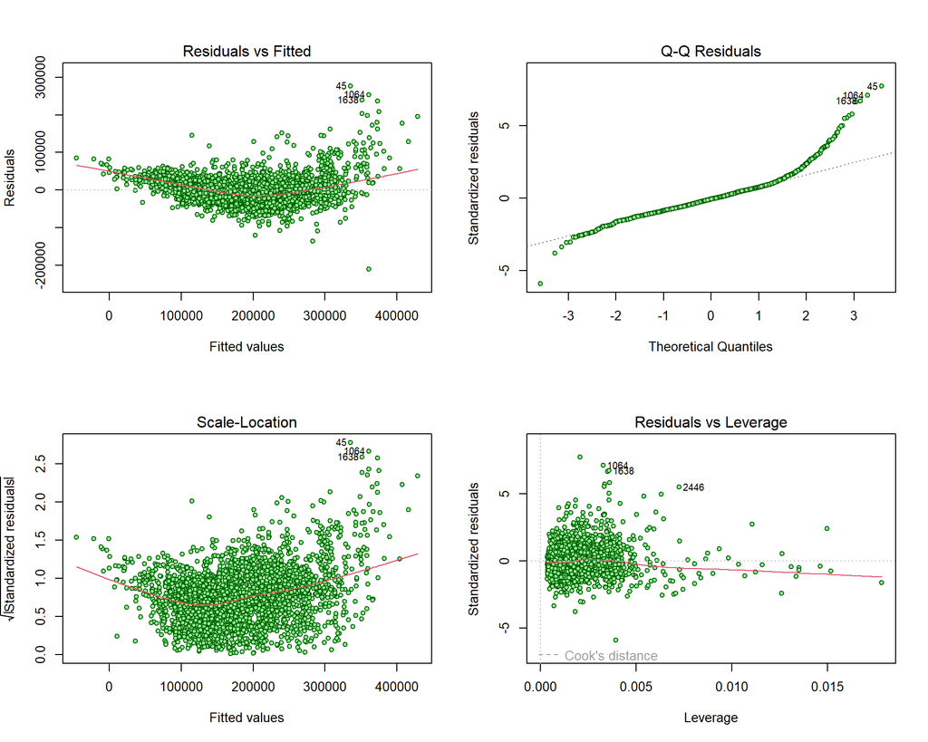

```r
par(mfrow = c(2, 2))
plot(model2, which = 1, pch = 21, bg = "lightgreen", col = "darkgreen", cex = 0.8)
plot(model2, which = 2, pch = 21, bg = "lightgreen", col = "darkgreen", cex = 0.8)
plot(model2, which = 3, pch = 21, bg = "lightgreen", col = "darkgreen", cex = 0.8)
plot(model2, which = 5, pch = 21, bg = "lightgreen", col = "darkgreen", cex = 0.8)
```

```r
par(mfrow = c(1, 1))
```

## 7.3 Model 1 vs Model 2 Comparison

```r
model_comparison <- data.frame(
  Metric = c("R-squared", "Adjusted R-squared", "Residual Std Error", "Observations"),
  Model_1 = c(
    round(summary(model1)$r.squared, 7),
    round(summary(model1)$adj.r.squared, 7),
    round(summary(model1)$sigma, 7),
    nobs(model1)
  ),
  Model_2 = c(
    round(summary(model2)$r.squared, 7),
    round(summary(model2)$adj.r.squared, 7),
    round(summary(model2)$sigma, 7),
    nobs(model2)
  )
)
print(model_comparison)
```

```
##               Metric       Model_1       Model_2
## 1          R-squared     0.7702673     0.7928498
## 2 Adjusted R-squared     0.7699531     0.7925660
## 3 Residual Std Error 38316.2150104 35777.7467588
## 4       Observations  2930.0000000  2925.0000000
```

```r
# Improvement check
if (summary(model2)$adj.r.squared > summary(model1)$adj.r.squared) {
  cat("Model 2 shows an improvement with a higher Adjusted R-squared than Model 1.\n")
} else {
  cat("Model 2 does not improve upon Model 1.\n")
}
```

```
## Model 2 shows an improvement with a higher Adjusted R-squared than Model 1.
```

# 8 All Subsets Regression

## 8.1 Run Subsets Regression

```r
predictors <- c("OverallQual", "GrLivArea", "GarageArea", "HouseAge",
                "TotalBsmtSF", "X1stFlrSF", "FullBath", "TotRmsAbvGrd",
                "Fireplaces", "LotArea")
predictors <- predictors[predictors %in% names(ames_clean2)]

formula_str <- paste("SalePrice ~", paste(predictors, collapse = " + "))

regfit_full <- regsubsets(as.formula(formula_str),
                          data = ames_clean2,
                          nvmax = length(predictors))

reg_summary <- summary(regfit_full)

best_cp   <- which.min(reg_summary$cp)
best_bic  <- which.min(reg_summary$bic)
best_adjr2 <- which.max(reg_summary$adjr2)

cat("Best model by Cp:", best_cp, "variables\n")
```

```
## Best model by Cp: 10 variables
```

```r
cat("Best model by BIC:", best_bic, "variables\n")
```

```
## Best model by BIC: 10 variables
```

```r
cat("Best model by Adjusted R²:", best_adjr2, "variables\n")
```

```
## Best model by Adjusted R²: 10 variables
```

## 8.2 Selection Criteria Plots

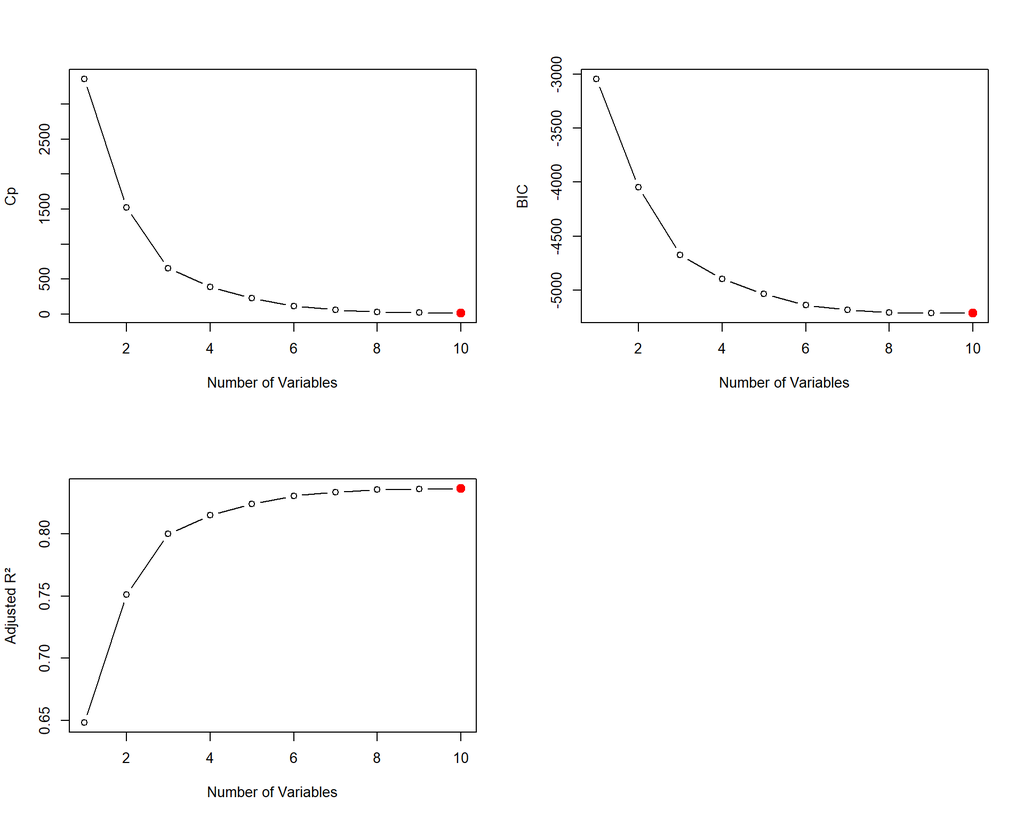

```r
par(mfrow = c(2, 2))
plot(reg_summary$cp,    xlab = "Number of Variables", ylab = "Cp",           type = "b")
points(best_cp,    reg_summary$cp[best_cp],       col = "red", cex = 2, pch = 20)

plot(reg_summary$bic,   xlab = "Number of Variables", ylab = "BIC",          type = "b")
points(best_bic,   reg_summary$bic[best_bic],     col = "red", cex = 2, pch = 20)

plot(reg_summary$adjr2, xlab = "Number of Variables", ylab = "Adjusted R²",  type = "b")
points(best_adjr2, reg_summary$adjr2[best_adjr2], col = "red", cex = 2, pch = 20)
par(mfrow = c(1, 1))
```

## 8.3 Fit Preferred Model

```r
best_model_vars <- names(coef(regfit_full, best_bic))[-1]
cat("Best model variables (by BIC):\n")
```

```
## Best model variables (by BIC):
```

```r
print(best_model_vars)
```

```
##  [1] "OverallQual"  "GrLivArea"    "GarageArea"   "HouseAge"     "TotalBsmtSF"
##  [6] "X1stFlrSF"    "FullBath"     "TotRmsAbvGrd" "Fireplaces"   "LotArea"
```

```r
formula_best <- paste("SalePrice ~", paste(best_model_vars, collapse = " + "))
model_preferred <- lm(as.formula(formula_best), data = ames_clean2)

summary(model_preferred)
```

```
##
## Call:
## lm(formula = as.formula(formula_best), data = ames_clean2)
##
## Residuals:
##     Min      1Q  Median      3Q     Max
## -199652  -18218   -1470   15184  244887
##
## Coefficients:
##                  Estimate   Std. Error t value             Pr(>|t|)
## (Intercept)  -61002.09497   4573.26070 -13.339 < 0.0000000000000002 ***
## OverallQual   19728.55969    674.34719  29.256 < 0.0000000000000002 ***
## GrLivArea        59.90072      2.71729  22.044 < 0.0000000000000002 ***
## GarageArea       40.01289      3.64447  10.979 < 0.0000000000000002 ***
## HouseAge       -403.29158     27.31719 -14.763 < 0.0000000000000002 ***
## TotalBsmtSF      30.19563      2.44159  12.367 < 0.0000000000000002 ***
## X1stFlrSF         9.93409      2.80181   3.546             0.000398 ***
## FullBath      -8733.70545   1547.48804  -5.644        0.00000001823 ***
## TotRmsAbvGrd  -2011.80093    660.93143  -3.044             0.002356 **
## Fireplaces     6210.17949   1076.94585   5.766        0.00000000894 ***
## LotArea           0.73842      0.08177   9.031 < 0.0000000000000002 ***
## ---
## Signif. codes:  0 '***' 0.001 '**' 0.01 '*' 0.05 '.' 0.1 ' ' 1
##
## Residual standard error: 31780 on 2914 degrees of freedom
## Multiple R-squared:  0.8369, Adjusted R-squared:  0.8364
## F-statistic:  1495 on 10 and 2914 DF,  p-value: < 0.00000000000000022
```

## 8.4 Diagnostic Plots - Preferred Model

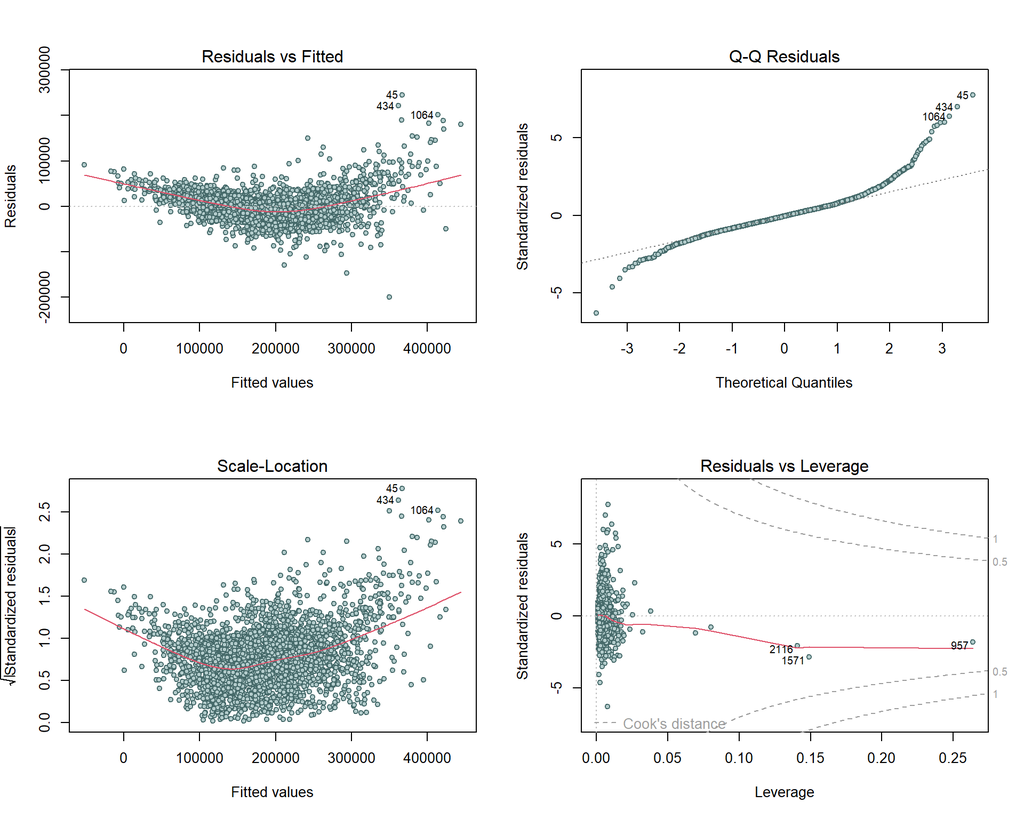

```r
par(mfrow = c(2, 2))
plot(model_preferred, which = 1, pch = 21, bg = "#b3cccc", col = "#476b6b", cex = 0.8)
plot(model_preferred, which = 2, pch = 21, bg = "#b3cccc", col = "#476b6b", cex = 0.8)
plot(model_preferred, which = 3, pch = 21, bg = "#b3cccc", col = "#476b6b", cex = 0.8)
plot(model_preferred, which = 5, pch = 21, bg = "#b3cccc", col = "#476b6b", cex = 0.8)
```

```r
par(mfrow = c(1, 1))
```

# 9 Model Comparison

```r
final_comparison <- data.frame(
  Metric = c("Variables", "R-squared", "Adj R-squared", "AIC", "BIC", "RSE"),
  Model_2 = c(
    paste(names(coef(model2))[-1], collapse = ", "),
    round(summary(model2)$r.squared, 4),
    round(summary(model2)$adj.r.squared, 4),
    round(AIC(model2), 2),
    round(BIC(model2), 2),
    round(summary(model2)$sigma, 2)
  ),
  Preferred_Model = c(
    paste(names(coef(model_preferred))[-1], collapse = ", "),
    round(summary(model_preferred)$r.squared, 4),
    round(summary(model_preferred)$adj.r.squared, 4),
    round(AIC(model_preferred), 2),
    round(BIC(model_preferred), 2),
    round(summary(model_preferred)$sigma, 2)
  )
)
print(final_comparison)
```

```
##          Metric                                      Model_2
## 1     Variables OverallQual, GrLivArea, GarageArea, HouseAge
## 2     R-squared                                       0.7928
## 3 Adj R-squared                                       0.7926
## 4           AIC                                     69645.51
## 5           BIC                                      69681.4
## 6           RSE                                     35777.75
##                                                                                                     Preferred_Model
## 1 OverallQual, GrLivArea, GarageArea, HouseAge, TotalBsmtSF, X1stFlrSF, FullBath, TotRmsAbvGrd, Fireplaces, LotArea
## 2                                                                                                            0.8369
## 3                                                                                                            0.8364
## 4                                                                                                          68957.86
## 5                                                                                                          69029.63
## 6                                                                                                           31777.4
```

```r
if (summary(model_preferred)$adj.r.squared > summary(model2)$adj.r.squared) {
  cat("PREFERRED: All Subsets Model\n")
  cat("Reason: Higher Adjusted R-squared and better model selection criteria\n")
} else {
  cat("PREFERRED: Model 2\n")
  cat("Reason: Similar performance with fewer variables (parsimony principle)\n")
}
```

```
## PREFERRED: All Subsets Model
## Reason: Higher Adjusted R-squared and better model selection criteria
```

# 10 Conclusion

This study demonstrated a complete regression modeling workflow using the Ames Housing dataset, emphasising both predictive performance and diagnostic validity. Through exploratory data analysis and correlation assessment, key predictors of housing sale prices were identified - overall quality, above-grade living area, garage area, and house age.

An initial regression model using these variables explained approximately **77%** of the variation in sale prices. Comprehensive diagnostic evaluation revealed mild heteroscedasticity and highly influential observations, particularly properties with above-grade living areas exceeding 4,000 sq ft. Removing these improved the adjusted R² to **0.79**.

# 11 References

- De Cock, D. (2011). Ames, Iowa: Alternative to the Boston housing data as an end of semester regression project. *Journal of Statistics Education, 19*(3). https://doi.org/10.1080/10691898.2011.11889627
- Fox, J., & Weisberg, S. (2019). *An R Companion to Applied Regression* (3rd ed.). Sage Publications.
- James, G., Witten, D., Hastie, T., & Tibshirani, R. (2021). *An Introduction to Statistical Learning with Applications in R* (2nd ed.). Springer.
- Lumley, T. (2020). *leaps: Regression subset selection* (R package version 3.1). https://CRAN.R-project.org/package=leaps
- R Core Team. (2024). *R: A language and environment for statistical computing*. https://www.R-project.org/
- Wei, T., & Simko, V. (2021). *corrplot: Visualization of a correlation matrix* (R package version 0.92). https://CRAN.R-project.org/package=corrplot
- Wickham, H., & Grolemund, G. (2017). *R for data science*. O’Reilly Media.